# Practice Code: Day 4

Author

Constantin Manuel Bosancianu

Published

August 1, 2019

# 1 Introduction

We start as yesterday, by loading a few needed packages, and by defining a few custom functions we use below.

```r
library(pacman)
p_load(tidyverse, ggeffects, texreg, arm, broom.mixed,
       ggthemes, interplot, HLMdiag, DHARMa, dotwhisker,
       knitr, kableExtra, magrittr)
```

We also define here a few helpful functions we will rely on in this code file.

```r
# Function from Zoltan Fazekas - it's a user-defined function, so it has to be
# re-loaded with exery new R session.
fun_two_SD <- function(x) {
        (x - mean(x, na.rm = TRUE)) / (2 * sd(x, na.rm = TRUE))
}
```

# 2 Data input and preparation

We’ll use the same data set as in the previous days. We’re keeping only the variables we’re interested in - compared to the previus days, I will add an additional level-2 predictor.

```r
df_issp <- readRDS("../02-data/01-ISSP.rds")

df_issp %<>%
    dplyr::select(cnt, year, country, poleff, female,
                  age10, educ, urban, incquart, ti_cpi,
                  gini10) %>%
    na.omit()

df_issp %<>%
    mutate(inc1 = if_else(incquart == 1, 1, 0),
           inc2 = if_else(incquart == 2, 1, 0),
           inc3 = if_else(incquart == 3, 1, 0),
           inc4 = if_else(incquart == 4, 1, 0))
```

## 2.1 Centering

Let’s go again through the centering procedures we went through yesterday, generate the last 3 models we looked at, and display the comparison table for the models.

```r
df_issp %<>%
    group_by(cnt) %>%
    mutate(age10CWC = fun_two_SD(age10),
           educCWC = fun_two_SD(educ),
           femCWC = fun_two_SD(female),
           urbanCWC = fun_two_SD(urban),
           inc1CWC = fun_two_SD(inc1),
           inc2CWC = fun_two_SD(inc2),
           inc3CWC = fun_two_SD(inc3),
           inc4CWC = fun_two_SD(inc4))
```

```r
df_agg <- df_issp %>%
    group_by(cnt) %>%
    summarise(ti_cpi = mean(ti_cpi, na.rm = TRUE),
              gini10 = mean(gini10, na.rm = TRUE)) %>%
    mutate(cpiCGM = fun_two_SD(ti_cpi),
           gini10CGM = fun_two_SD(gini10)) %>%
    dplyr::select(-ti_cpi, -gini10)
```

```r
df_issp <- left_join(df_issp, df_agg, by = c("cnt"))
rm(df_agg)
```

## 2.2 Initial specifications

We estimate 4 specifications, in increasing level of complexity, starting with the null model.

```r
mlm.0 <- lmer(poleff ~ 1 + (1 | cnt),
              data = df_issp,
              control = lmerControl(optimizer = "bobyqa"))
mlm.1 <- lmer(poleff ~ 1 + age10CWC + femCWC + educCWC +
                  urbanCWC + inc2CWC + inc3CWC + inc4CWC + cpiCGM +
                  (1 | cnt),
              data = df_issp,
              control = lmerControl(optimizer = "bobyqa"))
mlm.2 <- lmer(poleff ~ 1 + age10CWC + femCWC + educCWC +
                  urbanCWC + inc2CWC + inc3CWC + inc4CWC + cpiCGM +
                  (1 + educCWC | cnt),
              data = df_issp,
              control = lmerControl(optimizer = "bobyqa"))
mlm.3 <- lmer(poleff ~ 1 + age10CWC + femCWC + educCWC +
                  urbanCWC + inc2CWC + inc3CWC + inc4CWC + cpiCGM +
                  educCWC * cpiCGM + (1 + educCWC | cnt),
              data = df_issp,
              control = lmerControl(optimizer = "bobyqa"))
```

# 3 Model fit

As you could see in the previous days, the `summary()` function doesn’t give you any indication about the model fit. A set of dedicated functions exist for this.

```r
logLik(mlm.1)
```

```
'log Lik.' -39462.9 (df=11)
```

```r
logLik(mlm.2)
```

```
'log Lik.' -39362.13 (df=13)
```

```r
logLik(mlm.3)
```

```
'log Lik.' -39360.93 (df=14)
```

You also have functions for AIC and BIC (there’s not much sense to have a function for deviance, since it’s computed as $-2 * logLik$).

```r
AIC(mlm.1)
```

```
[1] 78947.8
```

```r
AIC(mlm.2)
```

```
[1] 78750.27
```

```r
AIC(mlm.3)
```

```
[1] 78749.86
```

```r
BIC(mlm.1)
```

```
[1] 79041.69
```

```r
BIC(mlm.2)
```

```
[1] 78861.23
```

```r
BIC(mlm.3)
```

```
[1] 78869.36
```

For a test of whether the differences in fit are statistically significant, we can turn to the `anova()` function.

```r
anova(mlm.1, mlm.2, mlm.3)
```

```
Data: df_issp
Models:
mlm.1: poleff ~ 1 + age10CWC + femCWC + educCWC + urbanCWC + inc2CWC + inc3CWC + inc4CWC + cpiCGM + (1 | cnt)
mlm.2: poleff ~ 1 + age10CWC + femCWC + educCWC + urbanCWC + inc2CWC + inc3CWC + inc4CWC + cpiCGM + (1 + educCWC | cnt)
mlm.3: poleff ~ 1 + age10CWC + femCWC + educCWC + urbanCWC + inc2CWC + inc3CWC + inc4CWC + cpiCGM + educCWC * cpiCGM + (1 + educCWC | cnt)
      npar   AIC   BIC logLik deviance    Chisq Df Pr(>Chisq)
mlm.1   11 78885 78979 -39431    78863
mlm.2   13 78689 78800 -39332    78663 199.4736  2  < 2.2e-16 ***
mlm.3   14 78684 78804 -39328    78656   7.2965  1   0.006909 **
---
Signif. codes:  0 '***' 0.001 '**' 0.01 '*' 0.05 '.' 0.1 ' ' 1
```

The function automatically re-fits every model in the comparison with FIML as opposed to REML, and produces a comparison table for the 3 models.

Quick questions for clarification:

1. Why is $DF=2$ for the comparison between Model 1 and Model 2? What are the extra 2 parameters that are estimated in Model 2?
2. Which one is the better fitting model out of the 3?

As an additional specification, let’s also try a model that includes Gini as predictor for the intercept at L1.

```r
mlm.4 <- lmer(poleff ~ 1 + age10CWC + femCWC + educCWC +
                  urbanCWC + inc2CWC + inc3CWC + inc4CWC + cpiCGM +
                  gini10CGM + educCWC * cpiCGM + (1 + educCWC | cnt),
              data = df_issp,
              control = lmerControl(optimizer = "bobyqa"))
summary(mlm.4)
```

```
Linear mixed model fit by REML ['lmerMod']
Formula: poleff ~ 1 + age10CWC + femCWC + educCWC + urbanCWC + inc2CWC +
    inc3CWC + inc4CWC + cpiCGM + gini10CGM + educCWC * cpiCGM +
    (1 + educCWC | cnt)
   Data: df_issp
Control: lmerControl(optimizer = "bobyqa")

REML criterion at convergence: 78724.3

Scaled residuals:
    Min      1Q  Median      3Q     Max
-4.3103 -0.6728 -0.0112  0.6700  8.7720

Random effects:
 Groups   Name        Variance Std.Dev. Corr
 cnt      (Intercept) 0.07432  0.2726
          educCWC     0.01094  0.1046   -0.29
 Residual             0.47063  0.6860
Number of obs: 37628, groups:  cnt, 35

Fixed effects:
                Estimate Std. Error t value
(Intercept)     2.963145   0.046234  64.090
age10CWC        0.121616   0.007487  16.244
femCWC         -0.121016   0.007118 -17.001
educCWC         0.322669   0.019467  16.575
urbanCWC        0.044423   0.007207   6.164
inc2CWC         0.057079   0.008774   6.505
inc3CWC         0.113761   0.008949  12.712
inc4CWC         0.218900   0.009301  23.534
cpiCGM          0.267760   0.106317   2.519
gini10CGM      -0.063951   0.103126  -0.620
educCWC:cpiCGM  0.108093   0.038925   2.777

Correlation of Fixed Effects:
            (Intr) a10CWC femCWC edcCWC urbCWC in2CWC in3CWC in4CWC cpiCGM
age10CWC     0.000
femCWC       0.000  0.024
educCWC     -0.264  0.096 -0.003
urbanCWC     0.000 -0.007 -0.013 -0.057
inc2CWC      0.000  0.025  0.035 -0.039  0.005
inc3CWC      0.000  0.077  0.057 -0.071  0.002  0.515
inc4CWC      0.000  0.078  0.079 -0.115 -0.036  0.510  0.540
cpiCGM       0.000  0.000  0.001 -0.001  0.000  0.001  0.001  0.000
gini10CGM    0.000  0.000  0.001 -0.003  0.000  0.003  0.001  0.000  0.470
edcCWC:cCGM  0.000 -0.009 -0.005  0.001  0.001  0.000 -0.003 -0.007 -0.234
            g10CGM
age10CWC
femCWC
educCWC
urbanCWC
inc2CWC
inc3CWC
inc4CWC
cpiCGM
gini10CGM
edcCWC:cCGM  0.006
```

Is there maybe a differential effect of Gini on education groups, though?

```r
mlm.5 <- lmer(poleff ~ 1 + age10CWC + femCWC + educCWC +
                  urbanCWC + inc2CWC + inc3CWC + inc4CWC + cpiCGM +
                  gini10CGM + educCWC * cpiCGM + educCWC * gini10CGM +
                (1 + educCWC | cnt),
              data = df_issp,
              control = lmerControl(optimizer = "bobyqa"))
summary(mlm.5)
```

```
Linear mixed model fit by REML ['lmerMod']
Formula: poleff ~ 1 + age10CWC + femCWC + educCWC + urbanCWC + inc2CWC +
    inc3CWC + inc4CWC + cpiCGM + gini10CGM + educCWC * cpiCGM +
    educCWC * gini10CGM + (1 + educCWC | cnt)
   Data: df_issp
Control: lmerControl(optimizer = "bobyqa")

REML criterion at convergence: 78719.7

Scaled residuals:
    Min      1Q  Median      3Q     Max
-4.3072 -0.6730 -0.0110  0.6703  8.7698

Random effects:
 Groups   Name        Variance Std.Dev. Corr
 cnt      (Intercept) 0.073097 0.27036
          educCWC     0.008184 0.09046  -0.27
 Residual             0.470626 0.68602
Number of obs: 37628, groups:  cnt, 35

Fixed effects:
                   Estimate Std. Error t value
(Intercept)        2.963145   0.045854  64.621
age10CWC           0.121602   0.007484  16.248
femCWC            -0.121114   0.007117 -17.017
educCWC            0.323276   0.017324  18.661
urbanCWC           0.044417   0.007206   6.164
inc2CWC            0.056884   0.008774   6.483
inc3CWC            0.113726   0.008949  12.709
inc4CWC            0.219089   0.009300  23.558
cpiCGM             0.307930   0.106368   2.895
gini10CGM          0.019012   0.106285   0.179
educCWC:cpiCGM     0.046184   0.039708   1.163
educCWC:gini10CGM -0.124201   0.038787  -3.202

Correlation of Fixed Effects:
            (Intr) a10CWC femCWC edcCWC urbCWC in2CWC in3CWC in4CWC cpiCGM
age10CWC     0.000
femCWC       0.000  0.024
educCWC     -0.234  0.108 -0.003
urbanCWC     0.000 -0.007 -0.013 -0.064
inc2CWC      0.000  0.026  0.035 -0.044  0.005
inc3CWC      0.000  0.077  0.057 -0.080  0.002  0.515
inc4CWC      0.000  0.079  0.079 -0.129 -0.036  0.510  0.540
cpiCGM       0.000  0.000  0.000  0.000  0.000  0.000  0.000  0.000
gini10CGM    0.000  0.000  0.000  0.000  0.000  0.000  0.000  0.000  0.485
edcCWC:cCGM  0.000 -0.010 -0.003 -0.005  0.001  0.005  0.000 -0.006 -0.236
edCWC:10CGM  0.000 -0.001  0.005 -0.012  0.000  0.011  0.004  0.000 -0.117
            g10CGM eCWC:C
age10CWC
femCWC
educCWC
urbanCWC
inc2CWC
inc3CWC
inc4CWC
cpiCGM
gini10CGM
edcCWC:cCGM -0.115
edCWC:10CGM -0.242  0.495
```

Which one fits the data better?

```r
anova(mlm.3, mlm.4, mlm.5)
```

```
Data: df_issp
Models:
mlm.3: poleff ~ 1 + age10CWC + femCWC + educCWC + urbanCWC + inc2CWC + inc3CWC + inc4CWC + cpiCGM + educCWC * cpiCGM + (1 + educCWC | cnt)
mlm.4: poleff ~ 1 + age10CWC + femCWC + educCWC + urbanCWC + inc2CWC + inc3CWC + inc4CWC + cpiCGM + gini10CGM + educCWC * cpiCGM + (1 + educCWC | cnt)
mlm.5: poleff ~ 1 + age10CWC + femCWC + educCWC + urbanCWC + inc2CWC + inc3CWC + inc4CWC + cpiCGM + gini10CGM + educCWC * cpiCGM + educCWC * gini10CGM + (1 + educCWC | cnt)
      npar   AIC   BIC logLik deviance  Chisq Df Pr(>Chisq)
mlm.3   14 78684 78804 -39328    78656
mlm.4   15 78686 78814 -39328    78656 0.3115  1   0.576750
mlm.5   16 78678 78815 -39323    78646 9.7776  1   0.001767 **
---
Signif. codes:  0 '***' 0.001 '**' 0.01 '*' 0.05 '.' 0.1 ' ' 1
```

# 4 Diagnostic checks

Let’s take Model 5, which seemed to be the most promising of all the specifications tested so far, at least if we judge based on the indices of model fit discussed earlier today and the LRT I conducted above.

Start from examining Level-1 residuals. A custom function for computing the within-group residuals is `hlm_resid()`.

```r
df_resid <- hlm_resid(mlm.5,
                      level = 1)
```

## 4.1 Linearity

Look at a plot of residuals vs. the outcome…

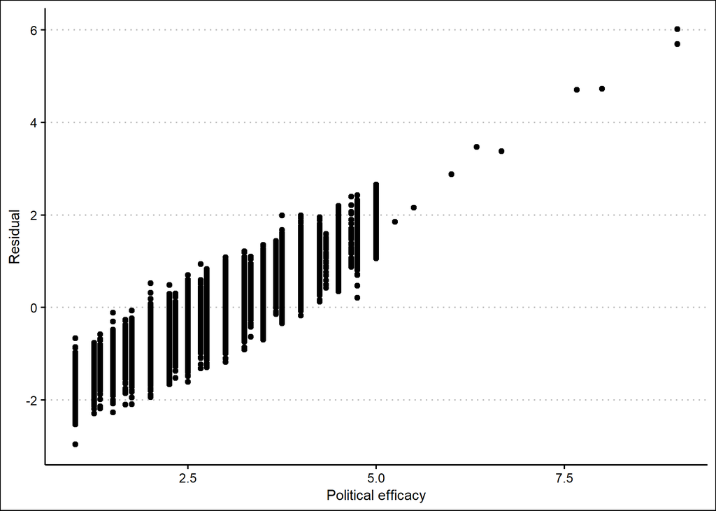

```r
ggplot(data = df_resid,
       aes(x = poleff,
           y = .resid)) +
    geom_point() +
    theme_clean() +
  labs(x = "Political efficacy",
       y = "Residual")
```

It’s normal that it’s tilted; getting rid of the tilt requires you to plot residuals against fitted values. Try it and see what comes out.

… as well as residuals against the predictors at L1

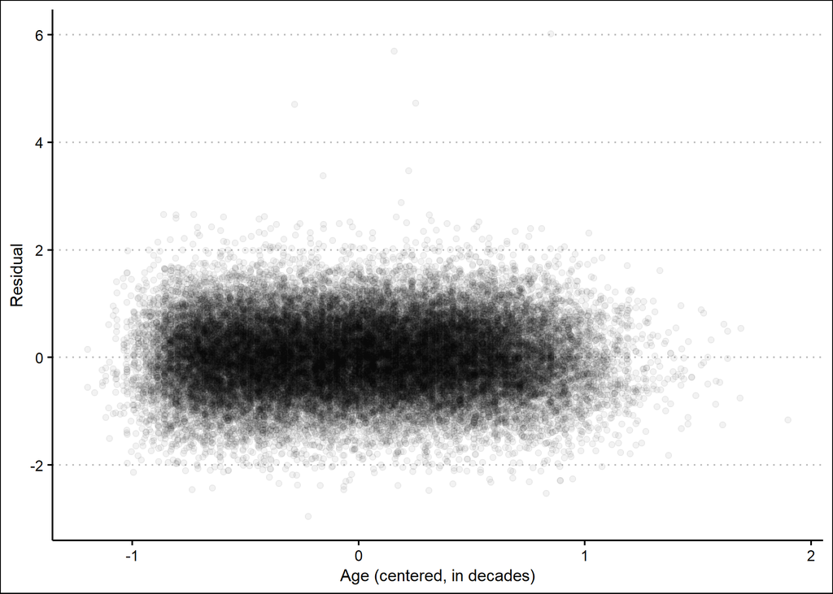

```r
ggplot(data = df_resid,
       aes(x = age10CWC,
           y = .resid)) +
    geom_point(alpha = 0.05) +
    theme_clean() +
  labs(x = "Age (centered, in decades)",
       y = "Residual")
```

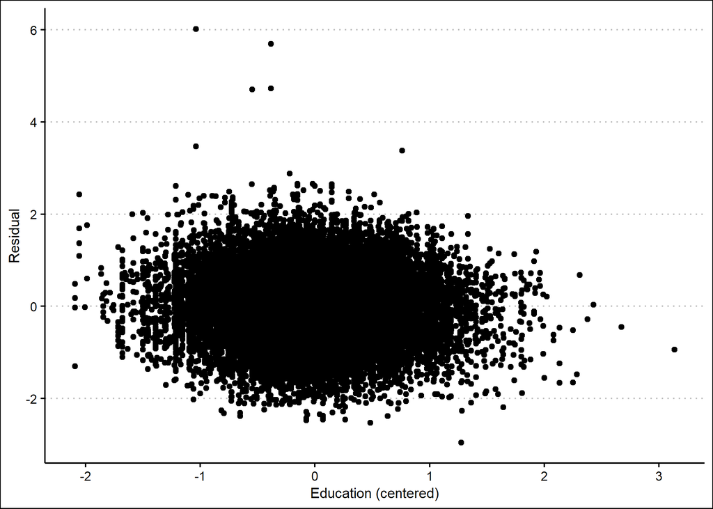

```r
ggplot(data = df_resid,
       aes(x = educCWC,
           y = .resid)) +
    geom_point() +
    theme_clean() +
  labs(x = "Education (centered)",
       y = "Residual")
```

With dichotomous predictors there is not much chance to diagnose a non-linear trend, so we won’t need to generate these plots.

## 4.2 Homogeneity of variance across groups

This is the Bartlett-Kendall test we discussed.

```r
bartlett.test(formula = .resid ~ cnt,
              data = df_resid)
```

```
    Bartlett test of homogeneity of variances

data:  .resid by cnt
Bartlett's K-squared = 463.36, df = 34, p-value < 2.2e-16
```

Unfortunately, we soundly reject $H_0$, which means that we do **NOT** have homogeneity of variances of residuals across countries.

```r
df_resid %>%
    group_by(cnt) %>%
    summarise(VAR = var(.resid)) %>%
    ungroup() %>%
    slice(1:15) %>%
    kable(caption = "Country-by-country variance of residuals",
          caption.above = TRUE,
          digits = 2,
          col.names = c("Country", "Residual variance"))
```

Country-by-country variance of residuals

| Country | Residual variance |
| --- | --- |
| AT | 0.51 |
| AU | 0.46 |
| BE | 0.50 |
| CH | 0.38 |
| CL | 0.40 |
| CZ | 0.52 |
| DE | 0.52 |
| DK | 0.62 |
| EE | 0.38 |
| ES | 0.50 |
| FI | 0.52 |
| FR | 0.34 |
| GB | 0.43 |
| GE | 0.46 |
| HR | 0.42 |

If this was an analysis intended for publishing there would be little reason to advance further, but for didactic purposes we can proceed.

## 4.3 Normally-distributed errors

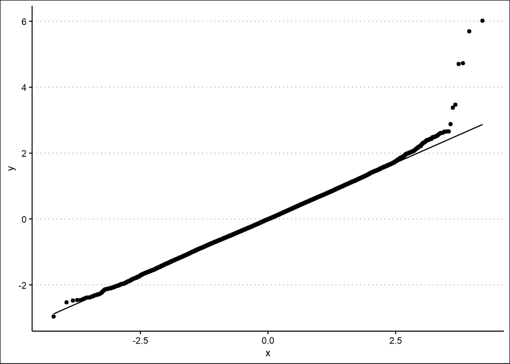

```r
ggplot(df_resid,
       aes(sample = .resid)) +
    stat_qq() +
    stat_qq_line() +
    theme_clean()
```

## 4.4 Level 2 residuals

We can do the same types of plots for the Level 2 residuals, only now we obviously only get one residual for each country.

```r
df_resid <- hlm_resid(mlm.5,
                      level = "cnt") %>%
    as.data.frame()
```

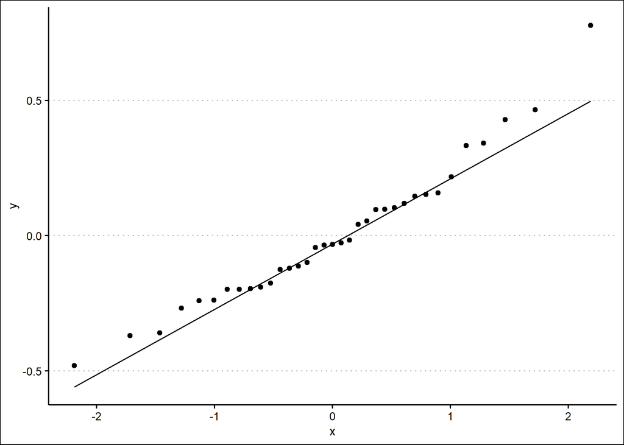

```r
ggplot(df_resid,
       aes(sample = .ranef.intercept)) +
    stat_qq() +
    stat_qq_line() +
    theme_clean()
```

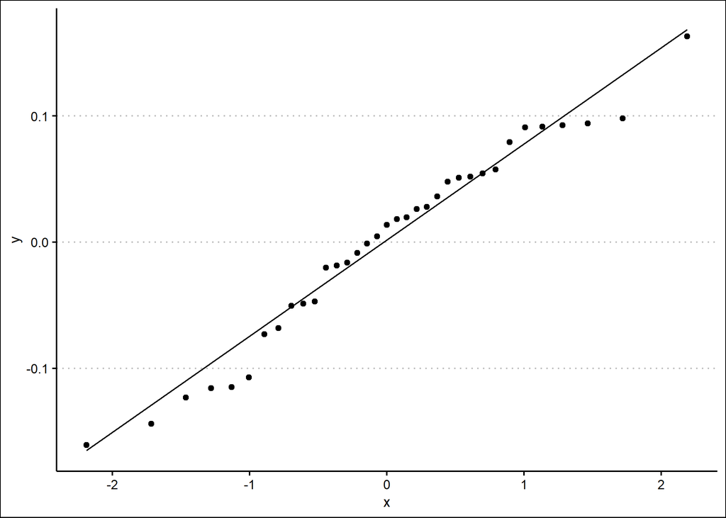

```r
ggplot(df_resid,
       aes(sample = .ranef.educ_cwc)) +
    stat_qq() +
    stat_qq_line() +
    theme_clean()
```

Keep in mind, though, that these are not residuals in the proper sense of the word, as we don’t know what the “true” slope is in a country. Instead, each residual is an assumption about what this slope is, which comes with its own uncertainty interval.

```r
ranef(mlm.5)
```

```
$cnt
   (Intercept)      educCWC
AT -0.19875454  0.050986663
AU  0.15786534 -0.068155520
BE -0.12543205 -0.050564989
CH  0.21722101  0.018129912
CL -0.02668507  0.097934968
CZ -0.19839797  0.079336502
DE  0.05371625  0.057589837
DK  0.09637863 -0.016330980
EE -0.19037225  0.004434091
ES -0.11269092  0.163057657
FI -0.09856012  0.091370130
FR  0.46568328 -0.047214067
GB -0.03299656 -0.008672283
GE -0.12039667  0.026217030
HR -0.26846919 -0.020141793
IL -0.23871591  0.051822884
IN -0.03528846 -0.160744199
IS  0.42862890 -0.115941637
JP  0.04141766 -0.144071652
KR -0.19639951  0.019741848
LT -0.36996615  0.013633297
NL  0.14519744  0.094139581
NO  0.34176765 -0.048707886
NZ  0.09730486 -0.115032487
PH  0.15198693 -0.107164675
PL -0.35974976 -0.072951423
RU  0.10291872  0.036281331
SE  0.11884518 -0.001118333
SI -0.48044711  0.054427593
SK -0.24016026 -0.018662554
TR  0.33326551 -0.123082898
TW -0.04422412  0.047898816
US -0.01650215  0.092610009
VE  0.77736894  0.027902531
ZA -0.17535751  0.091042697

with conditional variances for "cnt"
```

```r
se.ranef(mlm.5)
```

```
$cnt
   (Intercept)    educCWC
AT  0.02523909 0.04386562
AU  0.02398895 0.04219476
BE  0.01668830 0.03123589
CH  0.02169577 0.03897321
CL  0.02283165 0.04059436
CZ  0.02037335 0.03702293
DE  0.01780911 0.03305011
DK  0.01670809 0.03126832
EE  0.02997563 0.04966261
ES  0.01989647 0.03630309
FI  0.02207438 0.03951912
FR  0.02662697 0.04565077
GB  0.01889037 0.03475583
GE  0.01985476 0.03623972
HR  0.02674815 0.04580318
IL  0.02558785 0.04432109
IN  0.02109256 0.03809200
IS  0.02488781 0.04340218
JP  0.01992162 0.03634128
KR  0.01858292 0.03427530
LT  0.02515410 0.04375393
NL  0.01871383 0.03448034
NO  0.01956995 0.03580518
NZ  0.02891813 0.04843999
PH  0.01990484 0.03631581
PL  0.01574311 0.02967017
RU  0.02458232 0.04299529
SE  0.02451942 0.04291108
SI  0.02844191 0.04787619
SK  0.02176117 0.03906791
TR  0.02081882 0.03768744
TW  0.01879795 0.03461176
US  0.02021352 0.03678265
VE  0.02243743 0.04003739
ZA  0.01459662 0.02772829
```

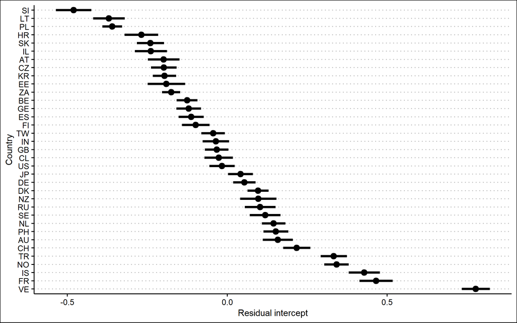

```r
df_resid <- data.frame(cnt = rownames(se.ranef(mlm.5)$cnt),
                       int = ranef(mlm.5)$cnt$`(Intercept)`,
                       se.int = se.ranef(mlm.5)$cnt[ ,1],
                       edu = ranef(mlm.5)$cnt$educCWC,
                       se.edu = se.ranef(mlm.5)$cnt[ ,2])

df_resid %>%
    ggplot(aes(x = reorder(cnt, -int),
               y = int)) +
    geom_point(size = 3) +
    labs(x = "Country",
         y = "Residual intercept") +
    theme_clean() +
    geom_errorbar(aes(ymin = int - 1.96 * se.int,
                      ymax = int + 1.96 * se.int),
                  linewidth = 1.25,
                  width = 0) +
    coord_flip()
```

Venezuela might be an outlier here.

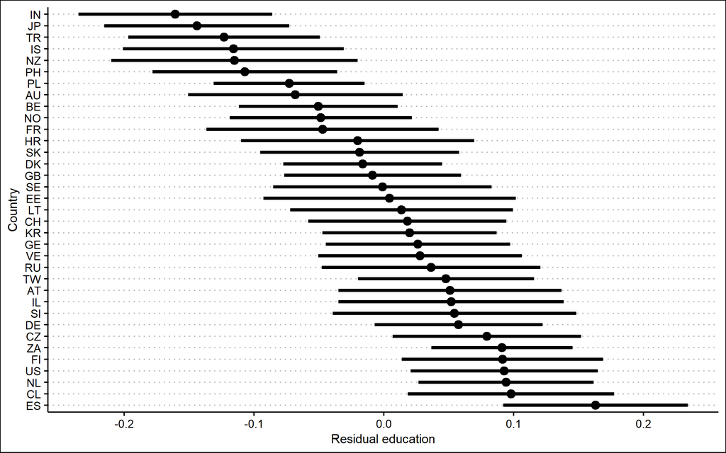

```r
df_resid %>%
    ggplot(aes(x = reorder(cnt, -edu),
               y = edu)) +
    geom_point(size = 3) +
    labs(x = "Country",
         y = "Residual education") +
    theme_clean() +
    geom_errorbar(aes(ymin = edu - 1.96 * se.edu,
                      ymax = edu + 1.96 * se.edu),
                  linewidth = 1.25,
                  width = 0) +
    coord_flip()
```

Things seem fine with the random effects for education.

We can continue with similar plots of predictors against residuals, to diagnose linearity, as well as visually assess constant variance.

# 5 Tasks

## 5.1 In class

Can you quickly extract from the ISSP for each country its value on `cpiCGM` and `gini10CGM`? Then please merge these into `df_resid` as additional columns, and use these for obtaining 2 plots, of predictors on X-axis and residuals on the Y-axis. All of the functions you need to do this have been introduced already.

## 5.2 At home

Load up again the ISSP data, and run a more complete specification at L1. Add to it religious attendance, as well as marital status, plus a quadratic term for age ($age^2$). Does this improve things in terms of residual variance across the countries?

# 6 Presenting results

At this point, after choosing the best fitting model and making all the diagnostic checks (and adjustments) you need to make, you would report the results from your models. You can present the null model, or leave it for the appendix - your call. You would typically also present 1-2 intermediate specifications (perhaps gradually adding more categories of predictors: attitudinal, institutional etc), and then the final specification. Either in the main body of the paper, or in the appendix, you would also present a few sensitivity checks.

Suppose that we had determined above that Model 5 truly **WAS** the best that we could do in terms of specification. How to present it?

## 6.1 Tables of coefficients

The standard approach is to display the table of coefficients directly in the paper. In here, the functions available in the `texreg` package are invaluable, though other packages that offer similar functionality exist as well.

```r
texreg(list(mlm.0, mlm.2, mlm.4, mlm.5),
       digits = 3,
       custom.model.names = c("Model 1","Model 2","Model 3","Model 4"),
       single.row = FALSE,
       custom.coef.names = c("(Intercept)", "Age (in decades)", "Gender (woman)",
                             "Education", "Urban residence", "Income: 2nd quantile",
                             "Income: 3rd quantile", "Income: 4th quantile",
                             "Corruption perceptions", "Gini (10-point units)",
                             "Education * Corruption perceptions",
                             "Education * Gini"),
       booktabs = TRUE,
       dcolumn = TRUE,
       use.packages = FALSE,
       caption = "Comparison of multilevel specifications for political efficacy",
       file = "../04-output/04-Table-mlm.tex")
```

```r
htmlreg(list(mlm.0, mlm.2, mlm.4, mlm.5),
        digits = 3,
        custom.model.names = c("Model 1","Model 2","Model 3","Model 4"),
        single.row = FALSE,
        custom.coef.names = c("(Intercept)", "Age (in decades)", "Gender (woman)",
                              "Education", "Urban residence", "Income: 2nd quantile",
                              "Income: 3rd quantile", "Income: 4th quantile",
                              "Corruption perceptions", "Gini (10-point units)",
                              "Education * Corruption perceptions",
                              "Education * Gini"),
        caption = "Comparison of multilevel specifications for political efficacy",
        file = "../04-output/04-Table-mlm.html")
```

## 6.2 Coefficient plots

Alternatively, you could choose to display coefficients as *dot-and-whisker* plots. Though there are canned functions available, the one I am most familiar with has severe limitations.

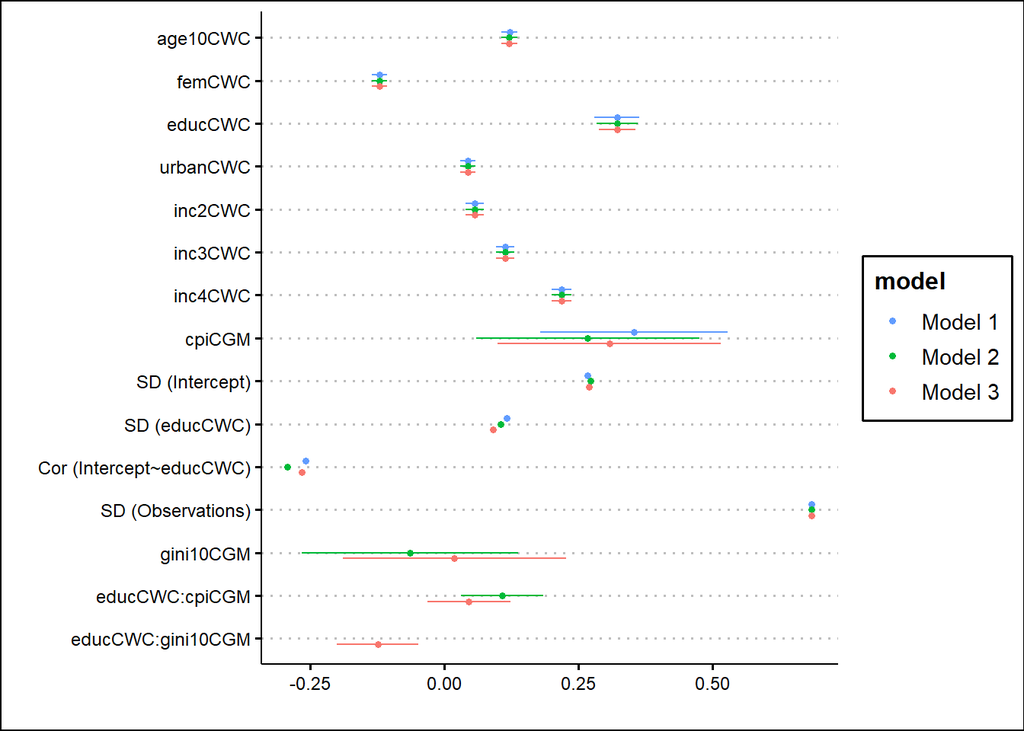

```r
dwplot(list(mlm.2, mlm.4, mlm.5),
       show_intercept = FALSE) +
    theme_clean()
```

This is why I show here the fully manual approach to plotting these quantities, even though it’s a bit long.

First step: tidy up model results and create an indicator variable that identifies the model from which they’re obtained.

```r
mod1tid <- tidy(mlm.2,
                effects = "fixed",
                conf.int = TRUE,
                conf.level = 0.95)
mod1tid <- mod1tid %>%
    dplyr::select(-c(effect)) %>%
    mutate(model = "model1")
mod2tid <- tidy(mlm.4,
                effects = "fixed",
                conf.int = TRUE,
                conf.level = 0.95)
mod2tid <- mod2tid %>%
    dplyr::select(-c(effect)) %>%
    mutate(model = "model2")
mod3tid <- tidy(mlm.5,
                effects = "fixed",
                conf.int = TRUE,
                conf.level = 0.95)
mod3tid <- mod3tid %>%
    dplyr::select(-c(effect)) %>%
    mutate(model = "model3")

df_modframe <- rbind(mod1tid, mod2tid, mod3tid)
rm(mod1tid, mod2tid, mod3tid)
```

Second stage: make variable names nice, and order coefficients based on the order in which they appear in the output of the most complete specification.

```r
df_modframe %<>%
    mutate(term = case_when(term %in% "(Intercept)" ~ "(Intercept)",
                            term %in% "age10CWC" ~ "Age (decades)",
                            term %in% "as.factor(female)1" ~ "Woman",
                            term %in% "educCWC" ~ "Education",
                            term %in% "as.factor(urban)1" ~ "Urban residence",
                            term %in% "as.factor(incquart)2" ~ "2nd income quartile",
                            term %in% "as.factor(incquart)3" ~ "3rd income quartile",
                            term %in% "as.factor(incquart)4" ~ "4th income quartile",
                            term %in% "cpiCGM" ~ "Perception of corruption",
                            term %in% "gini10CGM" ~ "Gini (10-points)",
                            term %in% "educCWC:cpiCGM" ~ "Education * Perceptions",
                            term %in% "educCWC:gini10CGM" ~ "Education * Gini"))

vec_term <- df_modframe$term[df_modframe$model == "model3"]
df_modframe$term <- factor(df_modframe$term,
                           levels = vec_term[length(vec_term):1],
                           ordered = TRUE)
rm(vec_term)
```

Final stage: plot the coefficients.

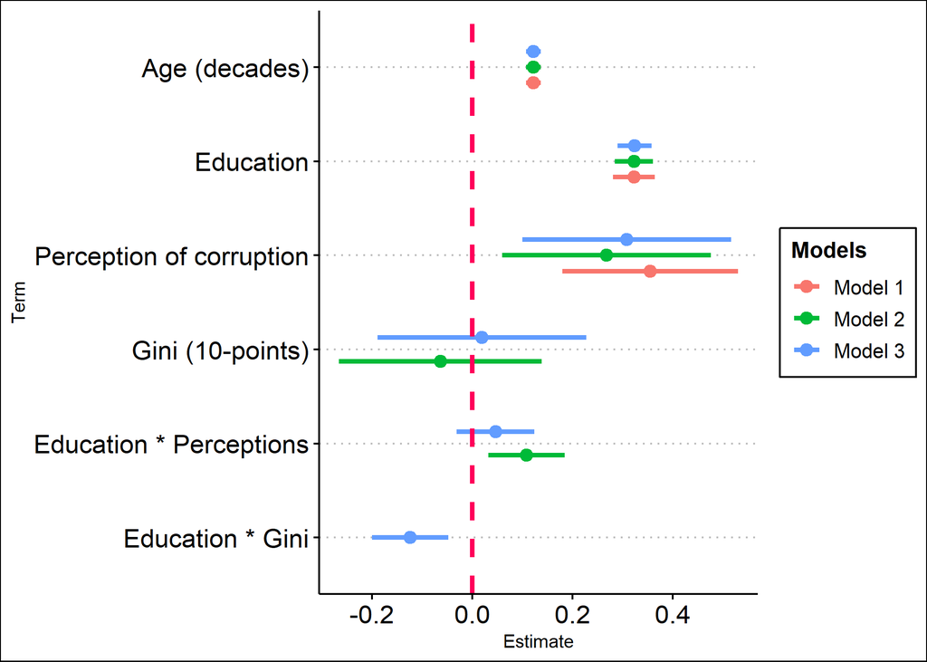

```r
df_modframe %>%
    dplyr::select(-c(std.error, statistic)) %>%
    filter(!(term == "(Intercept)")) %>%
    ggplot(aes(x = term, y = estimate, color = model)) +
    geom_point(size = 3,
               position = position_dodge(width = 0.5)) +
    geom_errorbar(aes(ymin = conf.low,
                      ymax = conf.high),
                  width = 0.,
                  linewidth = 1.25,
                  position = position_dodge(width = 0.5)) +
    geom_hline(yintercept = 0, linewidth = 1.25, linetype = "dashed",
               color = rgb(255, 0, 90, maxColorValue = 255)) +
      coord_flip() +
    labs(y = "Estimate",
         x = "Term") +
    theme_clean() +
    theme(axis.text.x = element_text(size = 14),
          axis.text.y = element_text(size = 14)) +
    scale_colour_discrete(name = "Models",
                          breaks = c("model1", "model2", "model3"),
                          labels = c("Model 1", "Model 2", "Model 3"))
```

```r
rm(df_modframe)
```

## 6.3 Marginal effects plot

Finally, if your focus is only on one of the effects, you can choose to present it using the standard marginal effects plot. Here as well it’s best to stick to a manual approach.

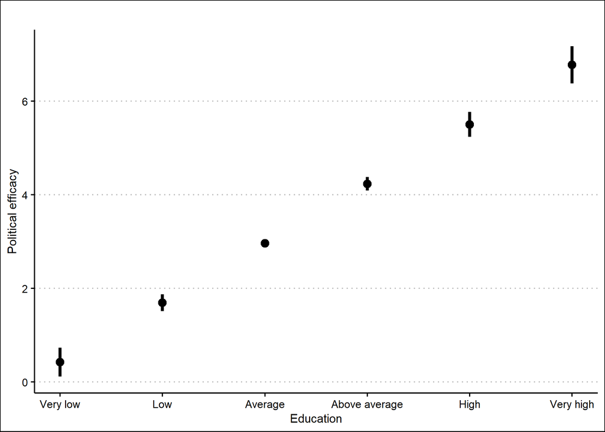

```r
pl1 <- ggpredict(mlm.5,
                 terms = "educCWC [-8, -4, 0, 4, 8, 12]",
                 type = "fe",
                 ci.lvl = 0.95)
ggplot(pl1,
       aes(x = x, y = predicted))  +
    geom_point(size = 3) +
    geom_errorbar(aes(ymin = conf.low,
                      ymax = conf.high),
                  width = 0,
                  linewidth = 1.25) +
    labs(y = "Political efficacy",
         x = "Education",
         title = "") +
    theme_clean() +
    scale_x_continuous(breaks = c(-8, -4, 0, 4, 8, 12),
                       labels = c("Very low","Low","Average","Above average",
                                  "High","Very high"))
```

```r
rm(pl1)
```

Alternatively, you can treat the variable as properly continuous.

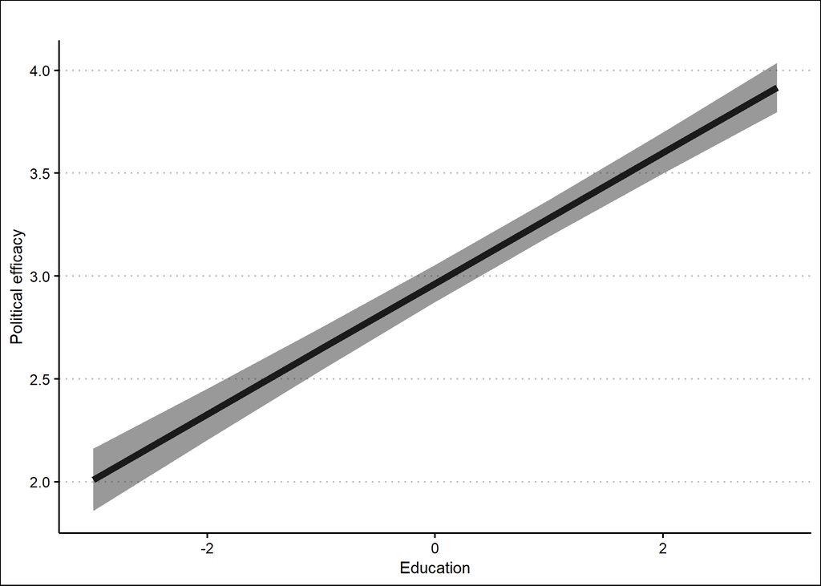

```r
pl2 <- ggpredict(mlm.5,
                 terms = "educCWC",
                 type = "fe",
                 ci.lvl = 0.95)
ggplot(pl2,
       aes(x = x, y = predicted))  +
    geom_line(linewidth = 2) +
    geom_ribbon(aes(ymin = conf.low,
                    ymax = conf.high),
                alpha = 0.5) +
    labs(y = "Political efficacy",
         x = "Education",
         title = "") +
    theme_clean()
```

# 7 Package versions